# Red Wine Analysis

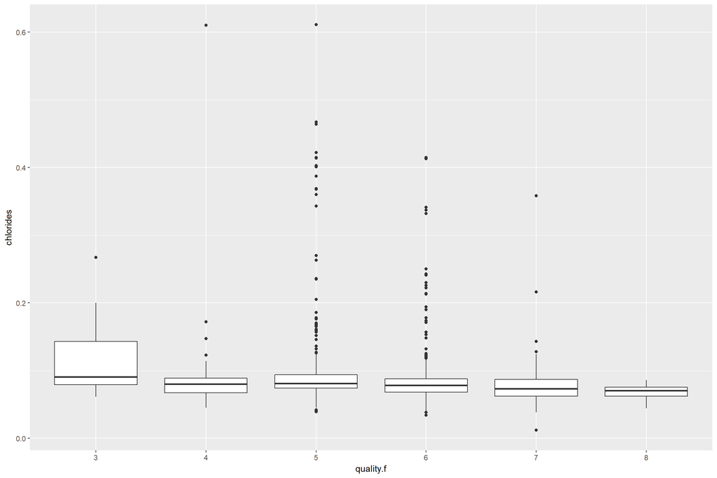

```r
ggplot(redwine,aes(x=quality.f, y=chlorides))+ geom_boxplot()
```

Free sulfur dioxide is the next variable. Free sulfur dioxide, the undissolved portion of sulfur dioxide is in mg per liter.

```
##    Min. 1st Qu.  Median    Mean 3rd Qu.    Max.
##    1.00    7.00   14.00   15.87   21.00   72.00
```

Total sulfur dioxide is the next variable. Total sulfur dioxide is the free and dissolved sulfur dioxide. Sulfur dioxide is used in wine to prevent microbial growth and oxidation of wine.

```
##    Min. 1st Qu.  Median    Mean 3rd Qu.    Max.
##    6.00   22.00   38.00   46.47   62.00  289.00
```

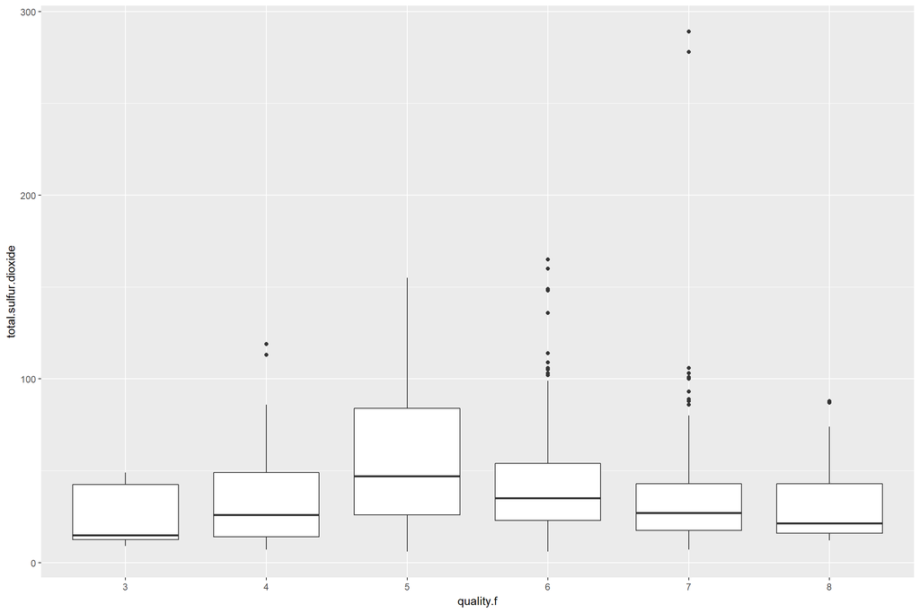

```r
ggplot(redwine,aes(x=quality.f, y=total.sulfur.dioxide))+ geom_boxplot()
```

Density is the next variable. In g/mL, the density is related to residual sugar and alcohol content.

```
##    Min. 1st Qu.  Median    Mean 3rd Qu.    Max.
##  0.9901  0.9956  0.9968  0.9967  0.9978  1.0040
```

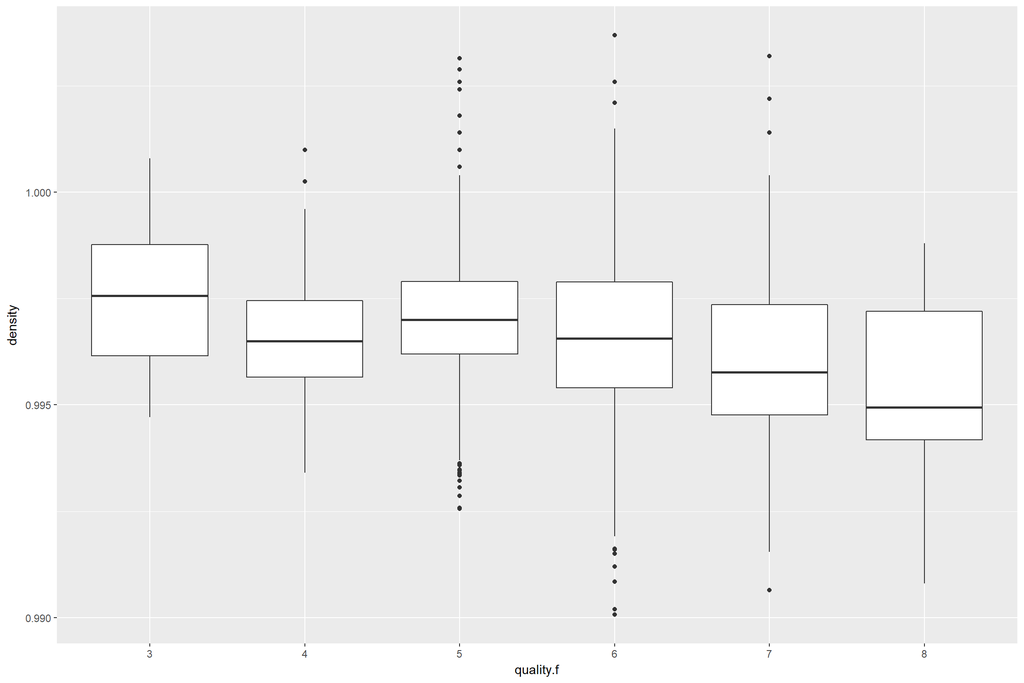

pH is the next variable. Most wines are between pH 3-4.

```
##    Min. 1st Qu.  Median    Mean 3rd Qu.    Max.
##   2.740   3.210   3.310   3.311   3.400   4.010
```

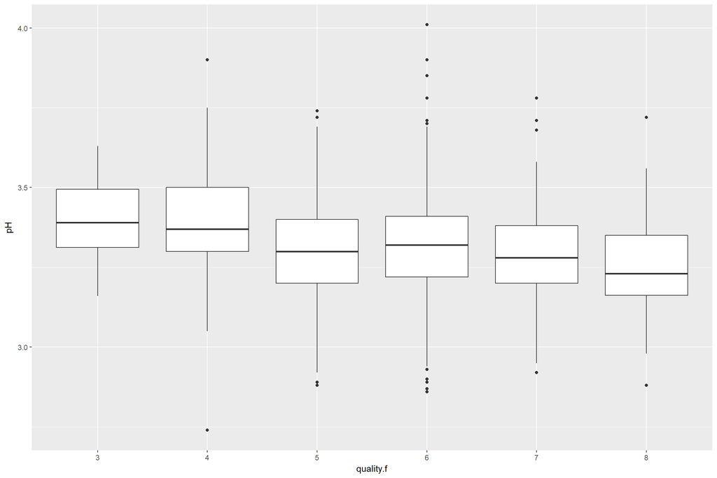

Sulphates is the next variable. Sulphates, measured by the amount of potassium sulphate per liter, are also used as antimicrobial agent in wine, contributing to the amount of sulfur dioxide in wine.

```
##    Min. 1st Qu.  Median    Mean 3rd Qu.    Max.
##  0.3300  0.5500  0.6200  0.6581  0.7300  2.0000
```

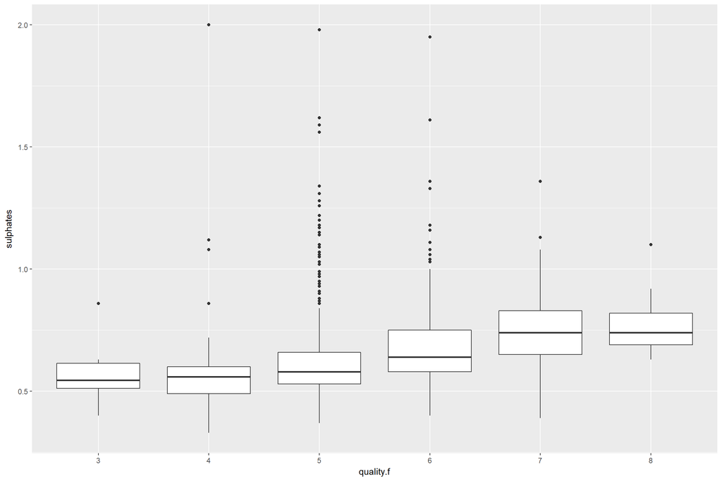

The last variable in this section is alcohol. Alcohol is measured by % volume.

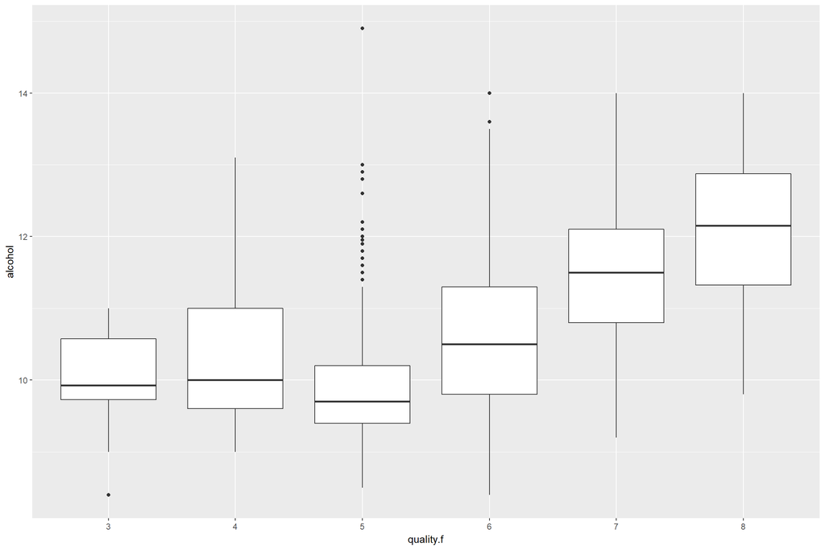

Now, I wanted to get a view of Quality distribution on the overall dataset; presented below.

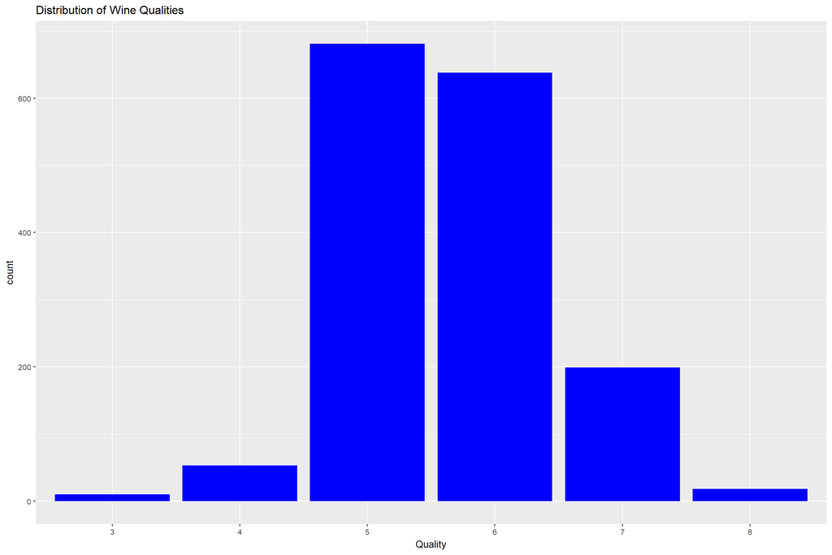

Now, with some understanding of the dataset Quality distribution and each variables distribution over quality, I wanted to dig a bit deeper on each variable. I noted from the variable summary information that some of the variables appeared to have a normal distribution while others did not. Thus, digging further, I wanted to see if transforming some of the variables would show a more revealing distribution and potential better use for regression analysis.

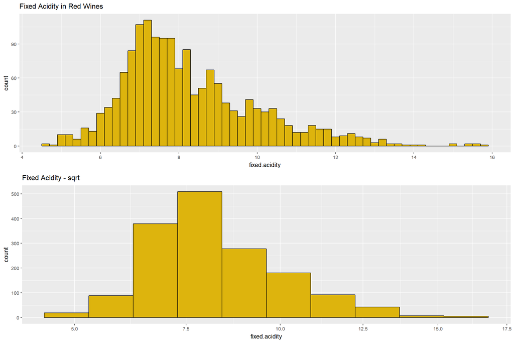

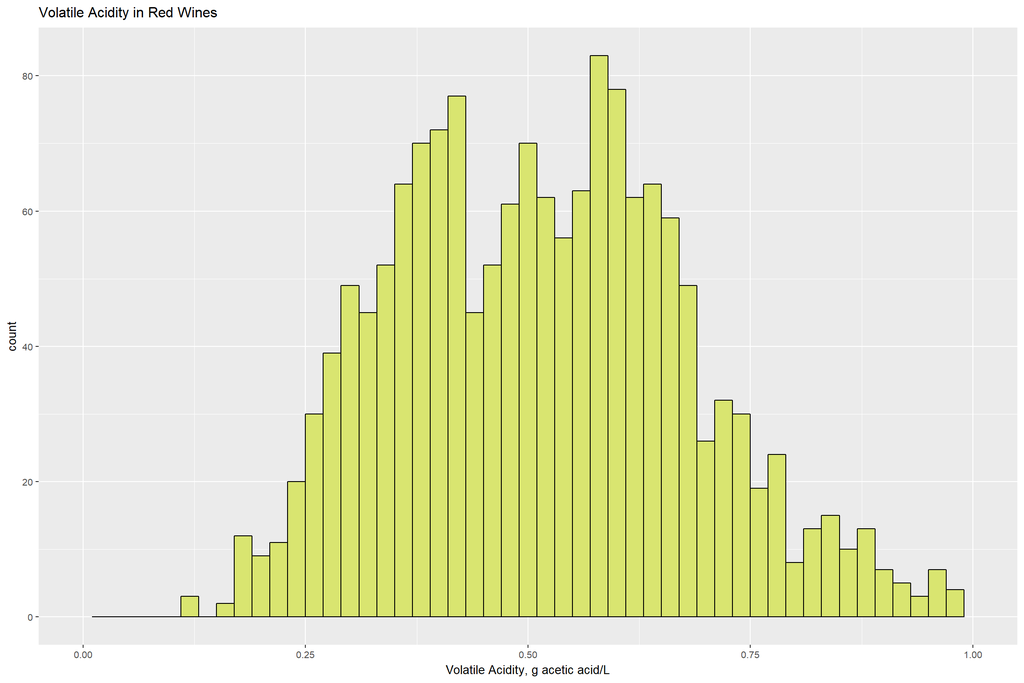

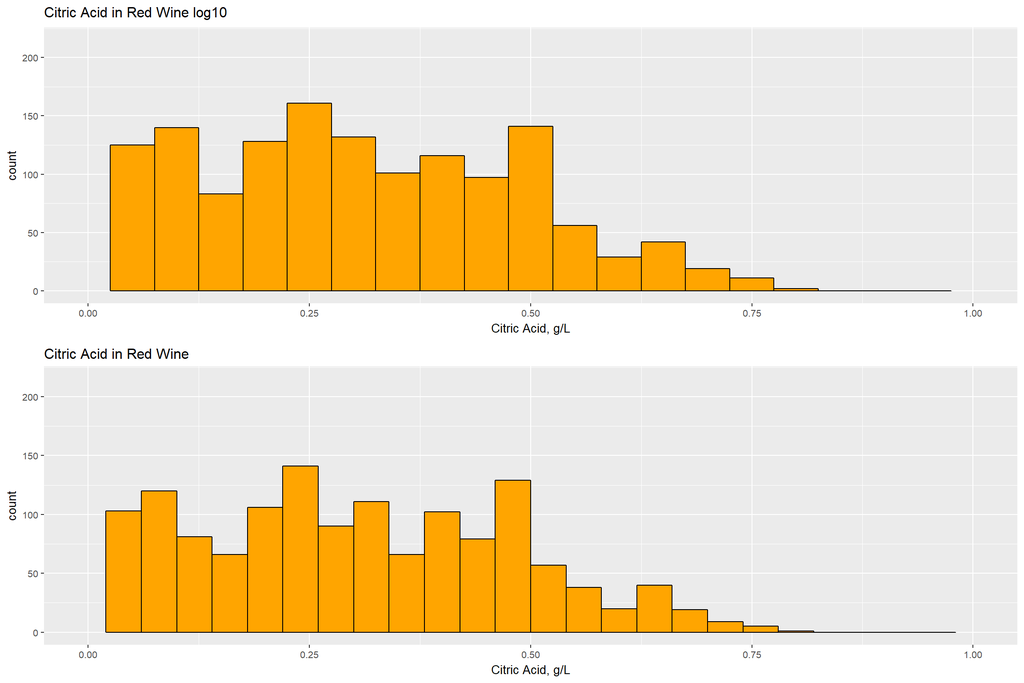

Residual sugar is not normally distributed.

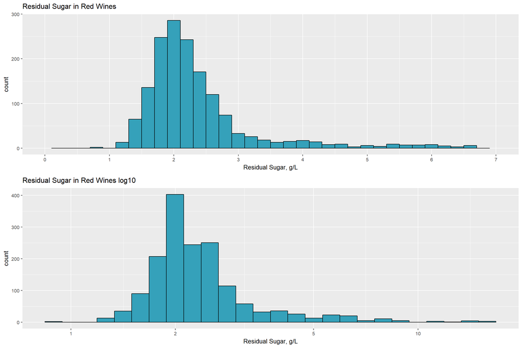

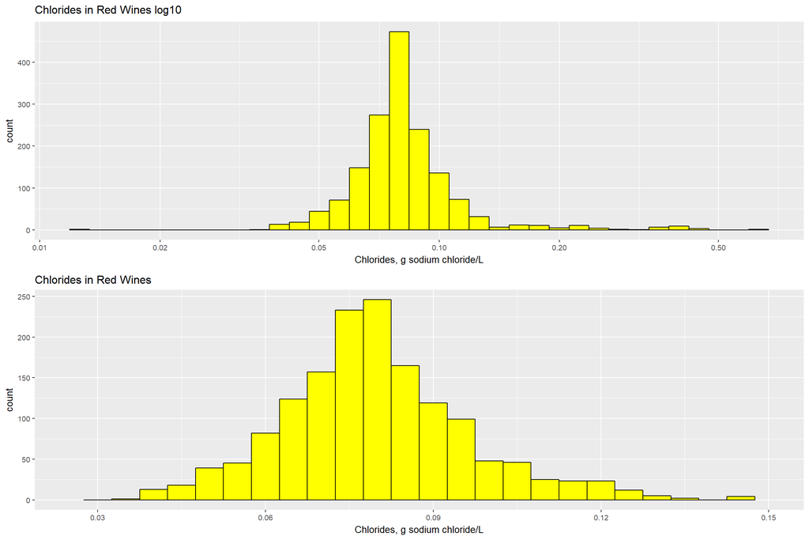

The variable Free Sulfur Dioxide shows a right side, long tail distribution. Transforming the data with log10 provides a more normal type distribution. As would be expected, Total Sulfur Dioxide has a similar distribution. The ratio of Free Sulfur Dioxide by Total Sulpfur Dioxide has a normal distribution.

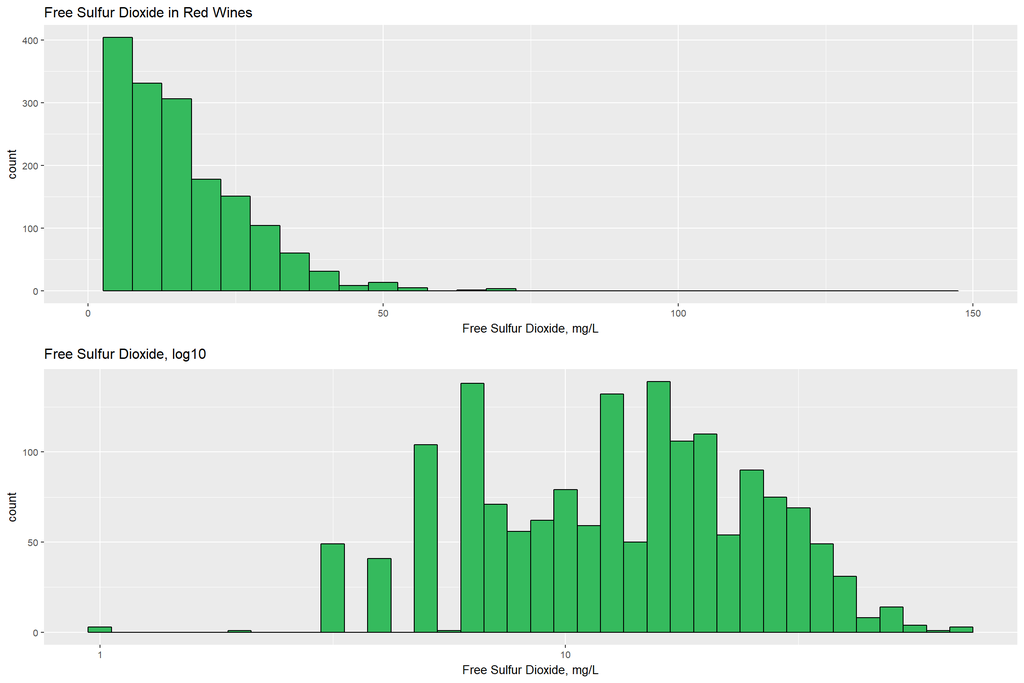

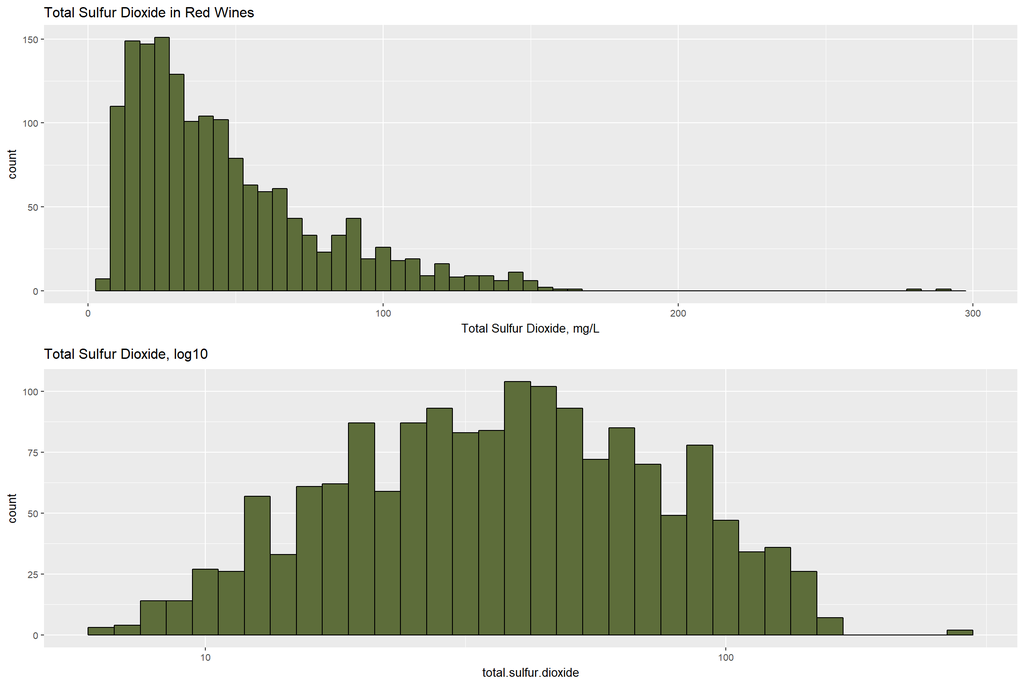

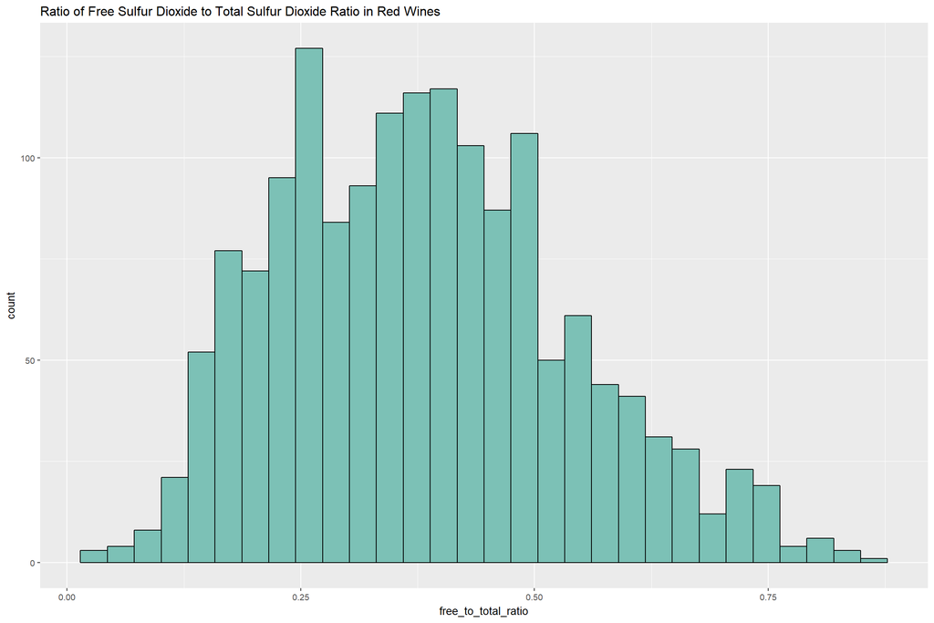

Density shows distribution and transformation showed the same normal distribution.

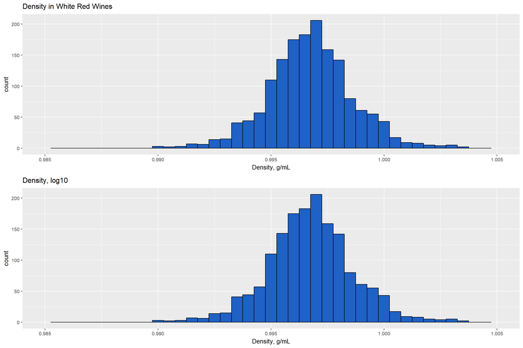

pH shows a normal distribution.

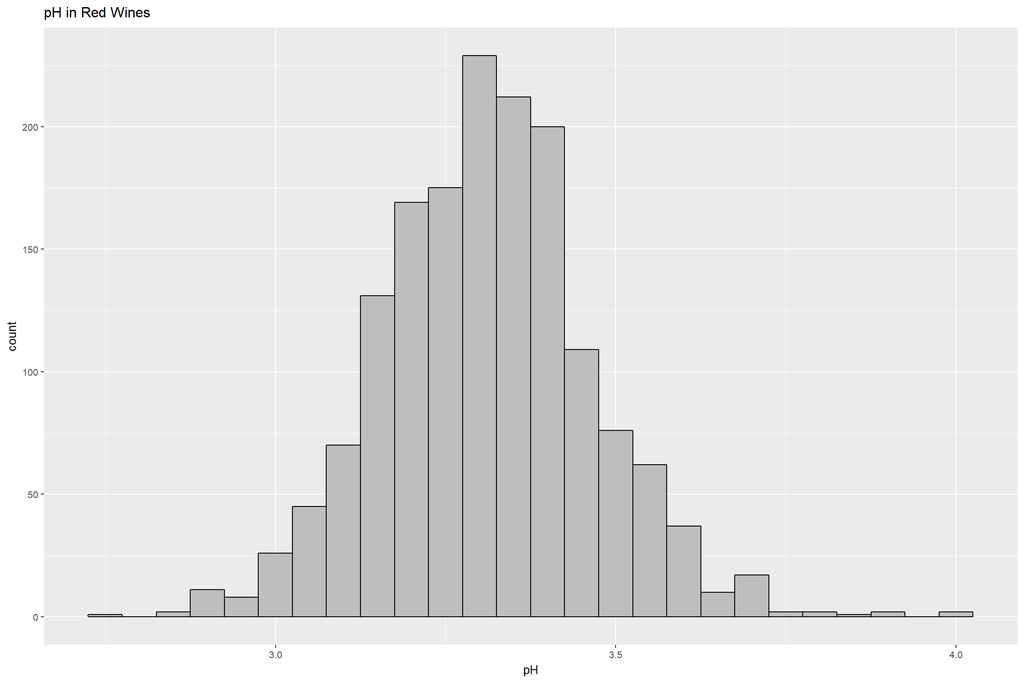

Transformation of Sulhates shows a slightly better defined distribution.

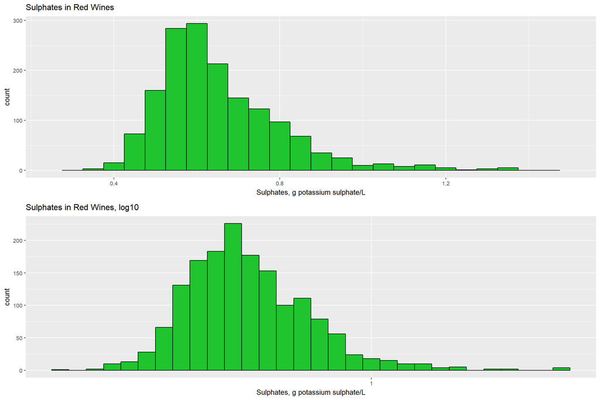

Alcohol does not show a normal distribution and transformation did show any significant insight.

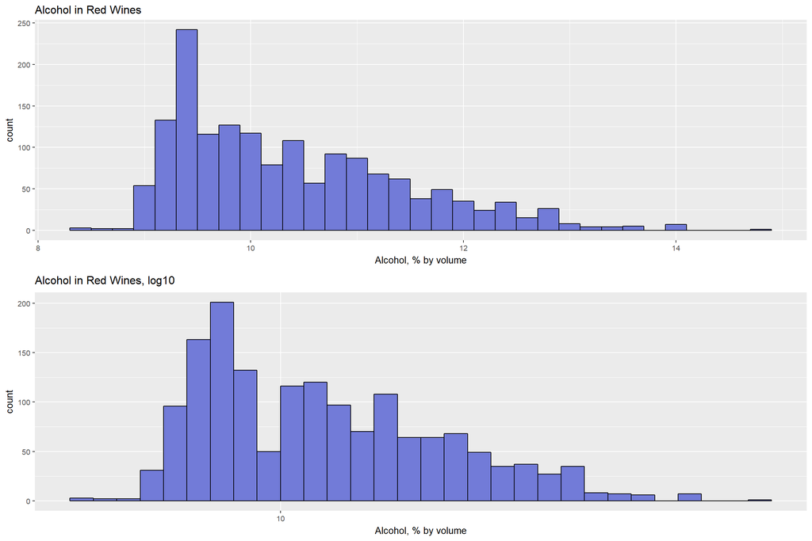

#Univariant Analysis

## What is the structure of your dataset?

The resulting “redwine” dataset has 1,599 observations and 13 variables and was downloaded from the Udacity project site. For this analysis the ‘x’ variable was coded null and the ‘quality’ int variable was used as an output variable by introducing a new factored variable ‘quality.f’.

## What is/are the main feature(s) of interest in your dataset?

The main features are the quality and alcohol variables. Quality values were determined by a panel of wine experts. The Quality histogram shows that most wines were classified as 5, 6 and 7. None of the wines were classified as 1, 2 or 10.

## Did you create any new variables from existing variables in the dataset?

I madea factor (ordered) variable out of “quality”. I also created a ratio between the free sulfur dioxide and total sulfur dioxide to see how the ratio distribution differed from the individual features. One could do a similar calculation ratio for citric acid to fixed acidity.

## Of the features you investigated, were there any unusual distributions? Did you perform any operations on the data to tidy, adjust, or change the form of the data? If so, why did you do this?

A lot of the features didn’t have a normal distribution and transforming them created distributions that approach the normal curve but not totally. Some didn’t change at all.

Fixed acidity is tailing, so transformation was done. The resulting histogram is more normally distributed.

Transformation of density also didn’t make the distribution better.

Alcohol distribution isn’t normal and transformation didn’t change the distribution.

Regarding tidying the data, the dataset was from the Udacity site provided the data had no missing data values. The only adjustment was to factor and order the Quality variable.

# Bivariate Plots Section

Building on insight from the previous Univariate review, I decided to group several of the variables at a time for analysis. The analysis below shows graphs and Pearson Correlation values using the ggpairs function.

The first group chart below supports prior ananlysis in showing that both alcohol and citric acid have a positive correlation with quality.

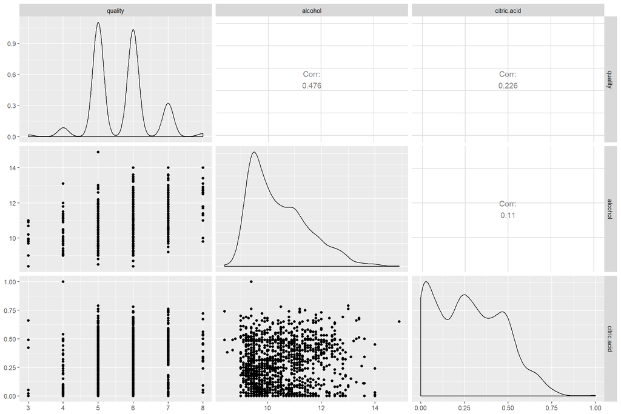

```r
g1 <- subset(redwine, select = c("quality", "alcohol", "citric.acid"))
ggpairs(g1)
```

The next correlation chart below further supports prior analysis by showing the negative correlation between quality and volatile acid and the positive correlation between quality and sulphates.

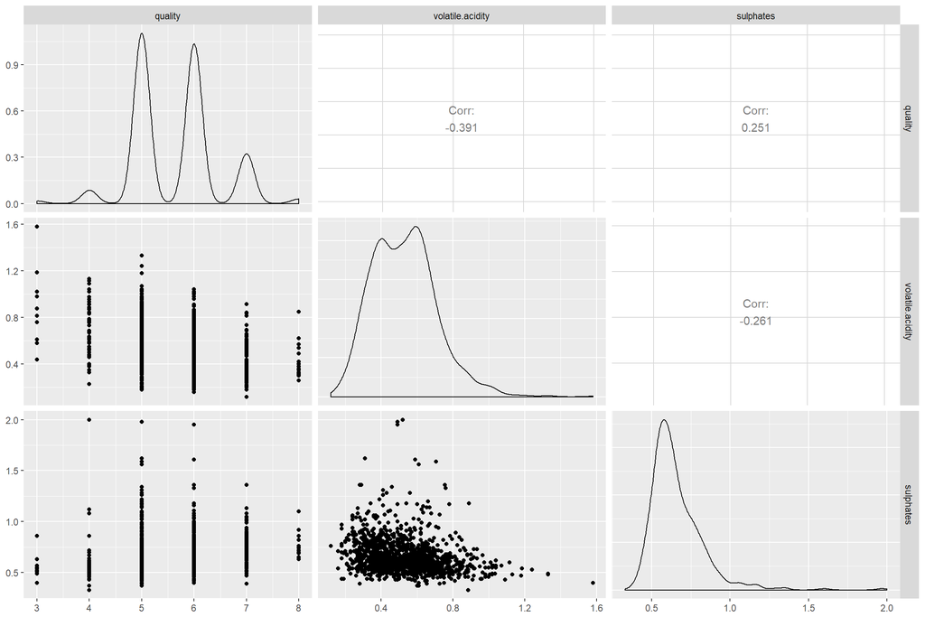

```r
g2 <- subset(redwine, select = c("quality", "volatile.acidity", "sulphates"))
ggpairs(g2)
```

As would be expected pH and citric acid have a strong negative correlation. Interestingly, sulphates and citric acid show a reasonably strong positive correlation.

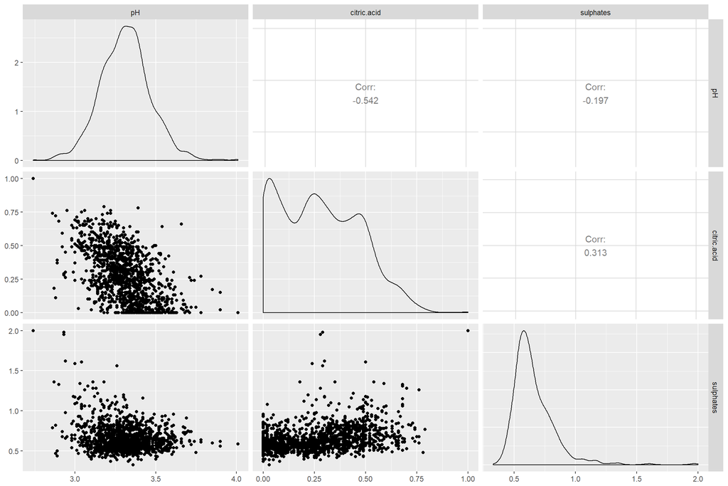

```r
g3 <- subset(redwine, select = c("pH", "citric.acid", "sulphates"))
ggpairs(g3)
```

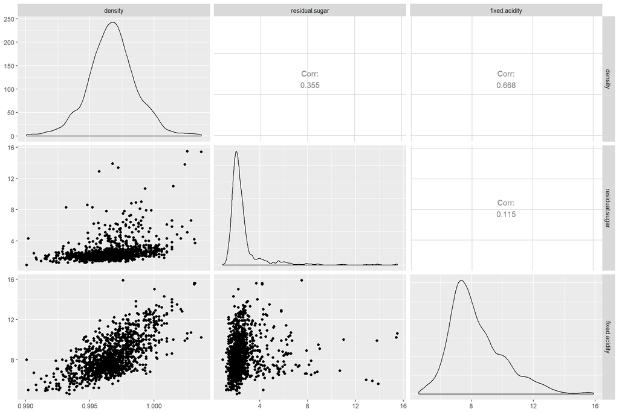

```r
g4 <- subset(redwine, select = c("density", "residual.sugar", "fixed.acidity"))
ggpairs(g4)
```

In order to look at the correlation amongst all of the variables, I used a table format as presented below:

```
##                                 X fixed.acidity volatile.acidity
## X                     1.000000000   -0.26848392     -0.008815099
## fixed.acidity        -0.268483920    1.00000000     -0.256130895
## volatile.acidity     -0.008815099   -0.25613089      1.000000000
## residual.sugar       -0.031260835    0.11477672      0.001917882
## chlorides            -0.119868519    0.09370519      0.061297772
## free.sulfur.dioxide   0.090479643   -0.15379419     -0.010503827
## total.sulfur.dioxide -0.117849669   -0.11318144      0.076470005
## density              -0.368372087    0.66804729      0.022026232
## pH                    0.136005328   -0.68297819      0.234937294
## sulphates            -0.125306999    0.18300566     -0.260986685
## free_to_total_ratio   0.335438942   -0.13081236     -0.072618561
##                      residual.sugar    chlorides free.sulfur.dioxide
## X                      -0.031260835 -0.119868519         0.090479643
## fixed.acidity           0.114776724  0.093705186        -0.153794193
## volatile.acidity        0.001917882  0.061297772        -0.010503827
## residual.sugar          1.000000000  0.055609535         0.187048995
## chlorides               0.055609535  1.000000000         0.005562147
## free.sulfur.dioxide     0.187048995  0.005562147         1.000000000
## total.sulfur.dioxide    0.203027882  0.047400468         0.667666450
## density                 0.355283371  0.200632327        -0.021945831
## pH                     -0.085652422 -0.265026131         0.070377499
## sulphates               0.005527121  0.371260481         0.051657572
## free_to_total_ratio    -0.070626080 -0.105156413         0.327240869
##                      total.sulfur.dioxide     density          pH
## X                             -0.11784967 -0.36837209  0.13600533
## fixed.acidity                 -0.11318144  0.66804729 -0.68297819
## volatile.acidity               0.07647000  0.02202623  0.23493729
## residual.sugar                 0.20302788  0.35528337 -0.08565242
## chlorides                      0.04740047  0.20063233 -0.26502613
## free.sulfur.dioxide            0.66766645 -0.02194583  0.07037750
## total.sulfur.dioxide           1.00000000  0.07126948 -0.06649456
## density                        0.07126948  1.00000000 -0.34169933
## pH                            -0.06649456 -0.34169933  1.00000000
## sulphates                      0.04294684  0.14850641 -0.19664760
## free_to_total_ratio           -0.37143493 -0.26497991  0.18489507
##                         sulphates free_to_total_ratio
## X                    -0.125306999          0.33543894
## fixed.acidity         0.183005664         -0.13081236
## volatile.acidity     -0.260986685         -0.07261856
## residual.sugar        0.005527121         -0.07062608
## chlorides             0.371260481         -0.10515641
## free.sulfur.dioxide   0.051657572          0.32724087
## total.sulfur.dioxide  0.042946836         -0.37143493
## density               0.148506412         -0.26497991
## pH                   -0.196647602          0.18489507
## sulphates             1.000000000         -0.01045914
## free_to_total_ratio  -0.010459139          1.00000000
```

# Bivariate Analysis

## Talk about some of the relationships you observed in this part of the investigation. How did the feature(s) of interest vary with other features in the dataset?

Using a matrix correlation on small groups of variables as I did above made it easier to pinpoint which input variables can contribute to classification of wine quality. These are alcohol, citric acid, sulphates (all positive correlation) and volatile acidity (negative correlation).

## What was the strongest relationship you found?

The strongest relationships between the output variable (quality) and input variables is the alcohol content.

Among other input variables, the strongest correlations are density and fixed acidity; free and total sulfur dioxide; pH and fixed acidity. The rest of the variable pairs are found to have correlations at a lower extent.

# Multivariate Plots Section

In this section, I wanted to focus on the correaltions noted in the previous summary section. Specifically, the variables with the strongest relationships to the output variable quality. Additionally, to review any relationships which may have been overlooked in prior single and bivariate analysis, I wanted to look at the strongest correletions between the other input variables from a multivariate approach.

The next several plots look at the four variables which show the strongest in fluenece on quality: alcohol, volatile acidity, citric acid and sulphates.

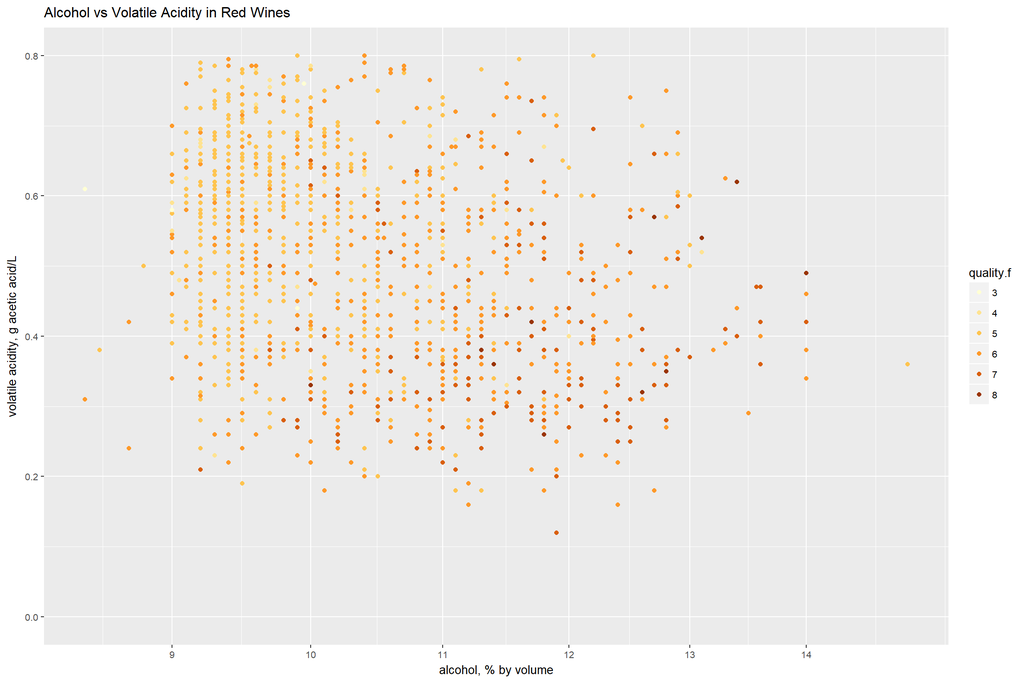

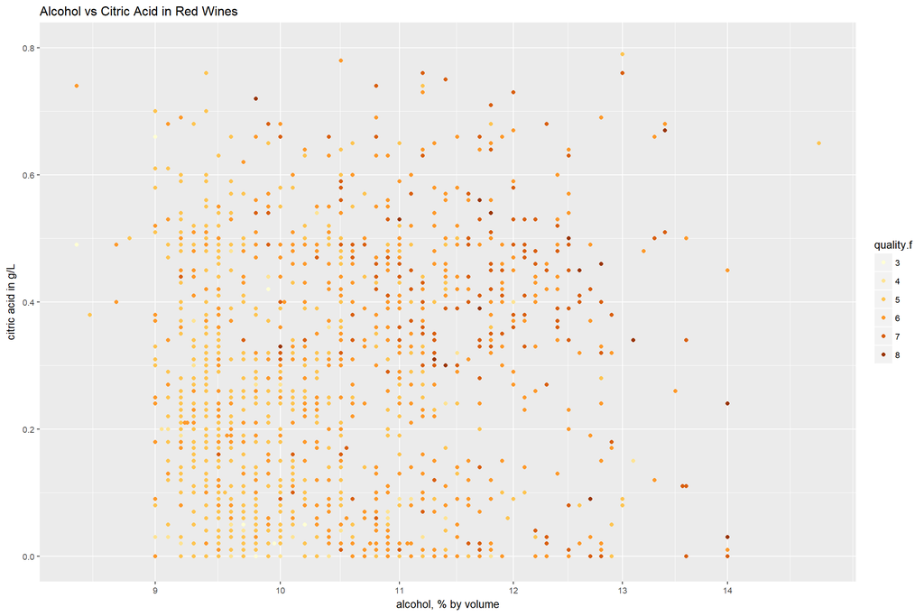

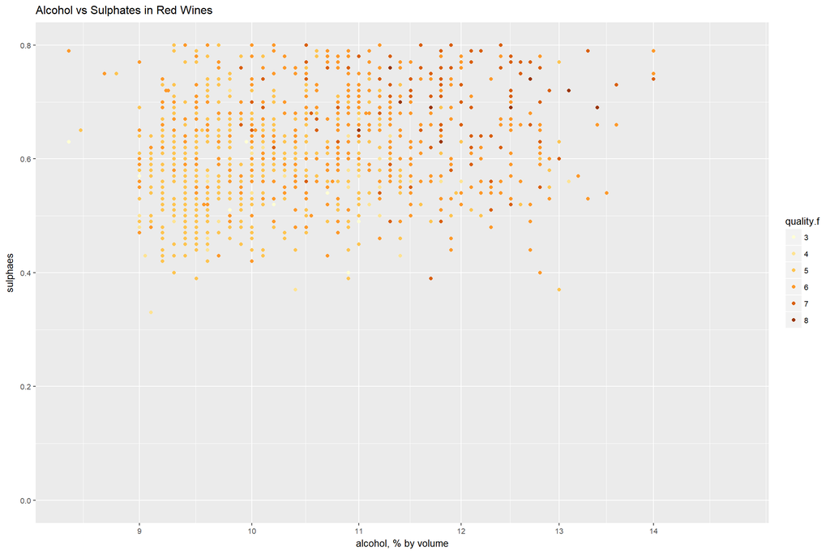

Now, combining three variables to classify the quality of Red Wines.

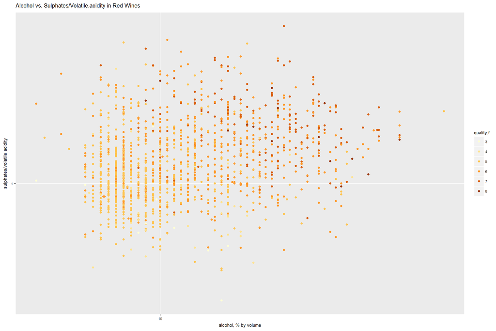